# Win Big Results

2024-05-18

# Experiment 1a

## **Participant Information**

**Pre-catch exclusion**

N = 192

| group | gender | n | age_mean | age_sd | age_median | age_IQR |
| --- | --- | --- | --- | --- | --- | --- |
| 1 | F | 38 | 19.447 | 3.644 | 18 | 1.75 |
| 1 | M | 28 | 19.607 | 2.347 | 19 | 2.00 |
| 2 | F | 39 | 20.179 | 4.667 | 19 | 2.00 |
| 2 | M | 24 | 19.375 | 1.952 | 19 | 2.00 |
| 3 | F | 38 | 19.132 | 1.711 | 18 | 1.75 |
| 3 | M | 25 | 20.320 | 3.198 | 19 | 3.00 |

**Post-catch exclusion**

N = 184

| group | gender | n | age_mean | age_sd | age_median | age_IQR |
| --- | --- | --- | --- | --- | --- | --- |
| 1 | F | 36 | 19.278 | 3.669 | 18 | 1 |
| 1 | M | 27 | 19.519 | 2.343 | 19 | 2 |
| 2 | F | 39 | 20.179 | 4.667 | 19 | 2 |
| 2 | M | 23 | 19.435 | 1.973 | 19 | 2 |
| 3 | F | 37 | 19.162 | 1.724 | 18 | 2 |
| 3 | M | 22 | 20.318 | 3.272 | 19 | 3 |

#### Condition totals:

| group | n | age_mean | age_sd | age_median | age_IQR |
| --- | --- | --- | --- | --- | --- |
| 1 | 63 | 19.381 | 3.149 | 19 | 1.5 |
| 2 | 62 | 19.903 | 3.887 | 19 | 2.0 |
| 3 | 59 | 19.593 | 2.457 | 19 | 2.0 |

- Total number of catch trial exclusions = 8.
- Catch trial exclusions were based on block 6 performance.

## **Catch Trials**

**Plot**

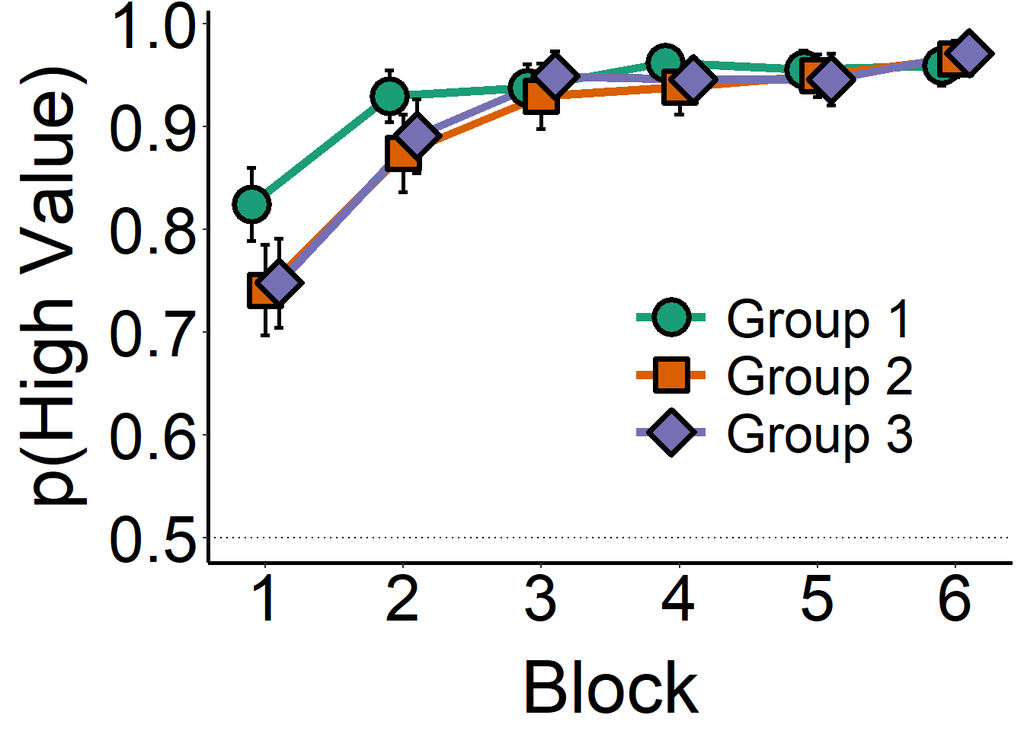

Errorbars = 95% CI

## **Risk Preference Trials**

**Plot**

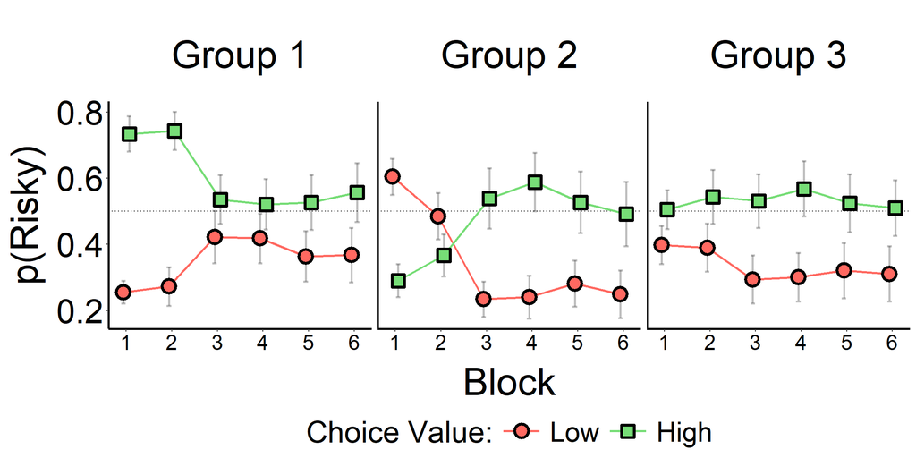

Errorbars = 95% CI

**Main Effects**

#### ANOVA Table

- Note: Blocks 2 and 5 were excluded from the analysis as their comparisons were deemed unnecessary.

|  | Model | df | AIC | BIC | logLik | Test | L.Ratio | p.value | R2 | BF_10 |
| --- | --- | --- | --- | --- | --- | --- | --- | --- | --- | --- |
| base_mod | 1 | 5 | 470.091 | 496.563 | -230.046 |  | NA | NA | NA | NA |
| grp_mod | 2 | 7 | 468.791 | 505.851 | -227.395 | 1 vs 2 | 5.300 | 0.071 | 0.013 | 1.000000e-02 |
| value_mod | 3 | 8 | 395.735 | 438.090 | -189.868 | 2 vs 3 | 75.055 | 0.000 | 0.187 | 5.177262e+14 |
| blk_mod | 4 | 11 | 392.410 | 450.648 | -185.205 | 3 vs 4 | 9.325 | 0.025 | 0.210 | 2.000000e-03 |
| grp_val | 5 | 13 | 393.681 | 462.507 | -183.840 | 4 vs 5 | 2.730 | 0.255 | 0.036 | 3.000000e-03 |
| grp_blk | 6 | 19 | 403.492 | 504.086 | -182.746 | 5 vs 6 | 2.188 | 0.902 | 0.007 | 0.000000e+00 |
| val_blk | 7 | 22 | 387.568 | 504.044 | -171.784 | 6 vs 7 | 21.925 | 0.000 | 0.067 | 1.021000e+00 |
| grp_val_blk | 8 | 28 | 173.864 | 322.107 | -58.932 | 7 vs 8 | 225.703 | 0.000 | 0.683 | 3.214768e+39 |

**Main Effect of Group:**

$\chi^2(2) = 5.3, p = 0.071, R^2_N = 0.01, BF_{10} < .01$

**Main Effect of Choice Value (i.e., Extreme Outcome effect):**

$\chi^2(1) = 75.06, p < .001, R^2_N = 0.19, BF_{10} > 150$

**Main Effect of Block:**

$\chi^2(3) = 9.33, p = 0.025, R^2_N = 0.21, BF_{10} < .01$

**Interaction: Group $\times$ Value:**

$\chi^2(2) = 2.73, p = 0.255, R^2_N = 0.04, BF_{10} < .01$

**Interaction: Group $\times$ Block:**

$\chi^2(6) = 2.19, p = 0.902, R^2_N = 0.01, BF_{10} < .01$

**Interaction: Value $\times$ Block:**

$\chi^2(3) = 21.92, p < .001, R^2_N = 0.07, BF_{10} = 1.021$

**Interaction: Group $\times$ Value $\times$ Block:**

$\chi^2(6) = 225.7, p < .001, R^2_N = 0.68, BF_{10} > 150$

#### Conclusion:

There is a 3-way interaction between Group, Value, and Block.

**Relevant Planned Contrasts**

#### **Comparing Blocks 1 and 3:**

Block (1 vs 3) $\times$ Group (1 vs 3) $\times$ Value (High vs Low):

$b = 0.12, t(1086) = 6.45, p < .001, r = 0.19$

Block (1 vs 3) $\times$ Group (2 vs 3) $\times$ Value (High vs Low):

$b = -0.12, t(1086) = -6.35, p < .001, r = 0.19$

#### Conclusion:

The difference between block 1 and 3 significantly interacts with both group and value.

#### **Comparing Blocks 4 and 6:**

Block (4 vs 6) $\times$ Group (1 vs 3) $\times$ Value (High vs Low):

$b = -0.04, t(1086) = -2, p = 0.046, r = 0.06$

Block (4 vs 6) $\times$ Group (2 vs 3) $\times$ Value (High vs Low):

$b = 0.01, t(1086) = 0.48, p = 0.631, r = 0.01$

#### Conclusion:

The difference between block 4 and 6 significantly interacts with group and value, but only when comparing group 1 and 3 (effect is small). There is no difference comparing group 2 and 3.

**Planned Contrasts (full list)**

|  | Value | Std.Error | DF | t.value | p.value | sig | r_effect | row |
| --- | --- | --- | --- | --- | --- | --- | --- | --- |
| (Intercept) | 0.427 | 0.023 | 1086 | 18.434 | 0.000 | TRUE | 0.488 | 1 |
| group g1_vs_g3 | 0.049 | 0.032 | 181 | 1.522 | 0.130 | FALSE | 0.112 | 2 |
| group g2_vs_g3 | -0.023 | 0.032 | 181 | -0.696 | 0.488 | FALSE | 0.052 | 3 |
| choice_value1 | 0.101 | 0.017 | 181 | 5.818 | 0.000 | TRUE | 0.397 | 4 |
| block b1b3_vs_b4b6 | 0.005 | 0.010 | 1086 | 0.507 | 0.612 | FALSE | 0.015 | 5 |
| block b1_vs_b3 | 0.020 | 0.014 | 1086 | 1.433 | 0.152 | FALSE | 0.043 | 6 |
| block b4_vs_b6 | 0.012 | 0.014 | 1086 | 0.870 | 0.384 | FALSE | 0.026 | 7 |
| group g1_vs_g3 :choice_value1 | 0.009 | 0.024 | 181 | 0.383 | 0.703 | FALSE | 0.028 | 8 |
| group g2_vs_g3 :choice_value1 | -0.029 | 0.024 | 181 | -1.175 | 0.242 | FALSE | 0.087 | 9 |
| group g1_vs_g3 :block b1b3_vs_b4b6 | 0.005 | 0.014 | 1086 | 0.403 | 0.687 | FALSE | 0.012 | 10 |
| group g2_vs_g3 :block b1b3_vs_b4b6 | 0.007 | 0.014 | 1086 | 0.537 | 0.591 | FALSE | 0.016 | 11 |
| group g1_vs_g3 :block b1_vs_b3 | -0.012 | 0.019 | 1086 | -0.616 | 0.538 | FALSE | 0.019 | 12 |
| group g2_vs_g3 :block b1_vs_b3 | 0.011 | 0.019 | 1086 | 0.560 | 0.575 | FALSE | 0.017 | 13 |
| group g1_vs_g3 :block b4_vs_b6 | -0.008 | 0.019 | 1086 | -0.436 | 0.663 | FALSE | 0.013 | 14 |
| group g2_vs_g3 :block b4_vs_b6 | 0.010 | 0.019 | 1086 | 0.528 | 0.598 | FALSE | 0.016 | 15 |
| choice_value1:block b1b3_vs_b4b6 | -0.015 | 0.010 | 1086 | -1.556 | 0.120 | FALSE | 0.047 | 16 |
| choice_value1:block b1_vs_b3 | -0.032 | 0.014 | 1086 | -2.354 | 0.019 | TRUE | 0.071 | 17 |
| choice_value1:block b4_vs_b6 | 0.017 | 0.014 | 1086 | 1.228 | 0.220 | FALSE | 0.037 | 18 |
| group g1_vs_g3 :choice_value1:block b1b3_vs_b4b6 | 0.053 | 0.014 | 1086 | 3.883 | 0.000 | TRUE | 0.117 | 19 |
| group g2_vs_g3 :choice_value1:block b1b3_vs_b4b6 | -0.060 | 0.014 | 1086 | -4.396 | 0.000 | TRUE | 0.132 | 20 |
| group g1_vs_g3 :choice_value1:block b1_vs_b3 | 0.124 | 0.019 | 1086 | 6.445 | 0.000 | TRUE | 0.192 | 21 |
| group g2_vs_g3 :choice_value1:block b1_vs_b3 | -0.122 | 0.019 | 1086 | -6.351 | 0.000 | TRUE | 0.189 | 22 |
| group g1_vs_g3 :choice_value1:block b4_vs_b6 | -0.038 | 0.019 | 1086 | -2.002 | 0.046 | TRUE | 0.061 | 23 |
| group g2_vs_g3 :choice_value1:block b4_vs_b6 | 0.009 | 0.019 | 1086 | 0.480 | 0.631 | FALSE | 0.015 | 24 |

# Experiment 1b

## **Participant Information**

**Pre-catch exclusion**

N = 190

| group | gender | n | age_mean | age_sd | age_median | age_IQR |
| --- | --- | --- | --- | --- | --- | --- |
| 1 | F | 48 | 19.500 | 3.156 | 18.0 | 1 |
| 1 | M | 13 | 19.231 | 1.787 | 19.0 | 1 |
| 2 | F | 38 | 18.842 | 1.636 | 18.0 | 1 |
| 2 | M | 25 | 19.840 | 1.748 | 19.0 | 2 |
| 3 | F | 50 | 19.220 | 3.699 | 18.5 | 1 |
| 3 | M | 16 | 19.375 | 1.544 | 19.0 | 2 |

**Post-catch exclusion**

N = 184

| group | gender | n | age_mean | age_sd | age_median | age_IQR |
| --- | --- | --- | --- | --- | --- | --- |
| 1 | F | 48 | 19.500 | 3.156 | 18 | 1 |
| 1 | M | 13 | 19.231 | 1.787 | 19 | 1 |
| 2 | F | 37 | 18.865 | 1.653 | 18 | 1 |
| 2 | M | 25 | 19.840 | 1.748 | 19 | 2 |
| 3 | F | 46 | 19.326 | 3.842 | 19 | 1 |
| 3 | M | 15 | 19.467 | 1.552 | 19 | 2 |

#### Condition totals:

| group | n | age_mean | age_sd | age_median | age_IQR |
| --- | --- | --- | --- | --- | --- |
| 1 | 61 | 19.443 | 2.907 | 18 | 1 |
| 2 | 62 | 19.258 | 1.746 | 19 | 2 |
| 3 | 61 | 19.361 | 3.411 | 19 | 1 |

- Total number of catch trial exclusions = 6.
- Catch trial exclusions were based on block 6 performance.

## **Catch Trials**

**Plot**

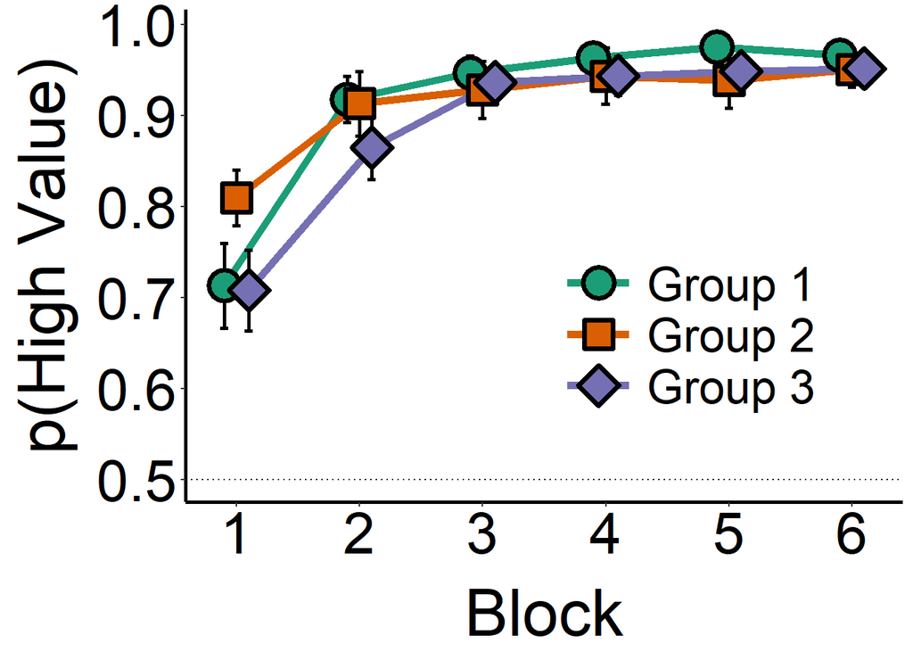

Errorbars = 95% CI

## **Risk Preference Trials**

**Plot**

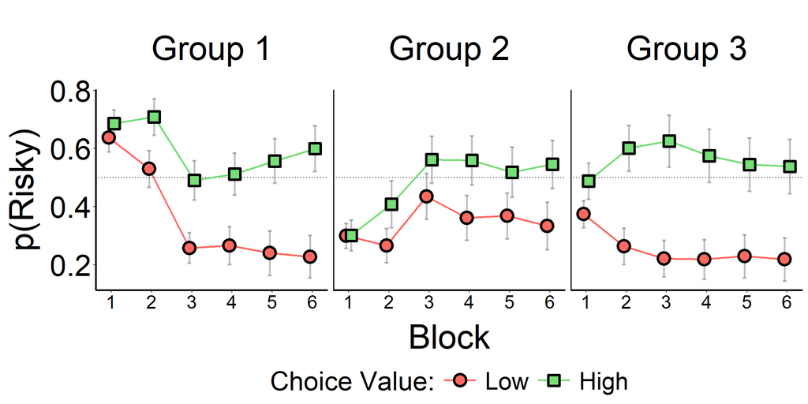

Errorbars = 95% CI

Blocks 1 - 4 Results

| group | block | choice_value | n | mean | sd | median | IQR |
| --- | --- | --- | --- | --- | --- | --- | --- |
| Group 1 | 1 | Low | 61 | 0.638 | 0.196 | 0.667 | 0.250 |
| Group 1 | 1 | High | 61 | 0.686 | 0.185 | 0.750 | 0.250 |
| Group 1 | 2 | Low | 61 | 0.530 | 0.248 | 0.500 | 0.333 |
| Group 1 | 2 | High | 61 | 0.709 | 0.243 | 0.750 | 0.333 |
| Group 1 | 3 | Low | 61 | 0.258 | 0.205 | 0.250 | 0.333 |
| Group 1 | 3 | High | 61 | 0.490 | 0.263 | 0.500 | 0.500 |
| Group 1 | 4 | Low | 61 | 0.266 | 0.256 | 0.167 | 0.500 |
| Group 1 | 4 | High | 61 | 0.512 | 0.280 | 0.583 | 0.417 |
| Group 2 | 1 | Low | 62 | 0.300 | 0.168 | 0.250 | 0.250 |
| Group 2 | 1 | High | 62 | 0.301 | 0.208 | 0.333 | 0.250 |
| Group 2 | 2 | Low | 62 | 0.266 | 0.233 | 0.167 | 0.333 |
| Group 2 | 2 | High | 62 | 0.409 | 0.320 | 0.333 | 0.646 |
| Group 2 | 3 | Low | 62 | 0.435 | 0.310 | 0.417 | 0.583 |
| Group 2 | 3 | High | 62 | 0.562 | 0.317 | 0.625 | 0.500 |
| Group 2 | 4 | Low | 62 | 0.362 | 0.303 | 0.333 | 0.500 |
| Group 2 | 4 | High | 62 | 0.559 | 0.331 | 0.625 | 0.583 |
| Group 3 | 1 | Low | 61 | 0.374 | 0.183 | 0.333 | 0.250 |
| Group 3 | 1 | High | 61 | 0.488 | 0.244 | 0.500 | 0.333 |
| Group 3 | 2 | Low | 61 | 0.264 | 0.245 | 0.167 | 0.333 |
| Group 3 | 2 | High | 61 | 0.601 | 0.307 | 0.583 | 0.500 |
| Group 3 | 3 | Low | 61 | 0.221 | 0.246 | 0.167 | 0.333 |
| Group 3 | 3 | High | 61 | 0.626 | 0.349 | 0.750 | 0.583 |
| Group 3 | 4 | Low | 61 | 0.219 | 0.268 | 0.083 | 0.333 |
| Group 3 | 4 | High | 61 | 0.575 | 0.356 | 0.667 | 0.667 |

R Core Team. (2023). *R: A language and environment for statistical computing*. R Foundation for Statistical Computing. https://www.R-project.org/